# Module 3 Project, Part B: Check Your Numbers

This is the output of one complete run of the project, with a fixed random seed. Use it to see whether your own results are in the right ballpark: the same order of magnitude, the same conclusions, the same first digit or two. It is not an answer key. There is no code and no explanation here, and the exam asks about *your* project, not this one.

What should match, and how closely:

- **Exact values** do not depend on random numbers and should match to every digit shown: everything in B.1(c), the jackknife SEs in B.1, and the training errors in B.3.
- **Bootstrap and cross-validation estimates** vary from run to run. Your bootstrap SEs, interval endpoints and cross-validated errors should agree with these to about two significant digits.
- **Times** depend on your computer.

# Part B: Leave one out

## B.1(a)

The jackknife SE, then the bootstrap SE from 2,000 samples.

```
##   jackknife   bootstrap
## 0.009442709 0.009523028
```

## B.1(c)

The sums below and above each value of `s <- c(1, 3, 4, 10)`, the vector `a` from the formula and from the definition, the check of `gini_loo` on the first 20 days, and the jackknife SE from `gini` and from `gini_loo`.

```
##       [,1] [,2] [,3] [,4]
## below    0    1    4    8
## above   17   14   10    0
```

```
##            [,1] [,2] [,3] [,4]
## formula      14   10   10   22
## definition   14   10   10   22
```

```
## [1] TRUE
```

```
##       outer      sorted
## 0.009442709 0.009442709
```

## B.2

The time for one jackknife SE with `gini`, in seconds, the minutes 2,000 of them would take, and the time for one with `gini_loo`.

```
##              one minutes_for_2000
##            2.622           87.400
```

```
##    user  system elapsed
##       0       0       0
```

The time for the bootstrap-$t$ loop, then the bootstrap-$t$ and percentile intervals.

```
##    user  system elapsed
##   6.721   0.008   6.735
```

```
##                  [,1]      [,2]
## bootstrap_t 0.4124927 0.4480901
## percentile  0.4106660 0.4482040
```

## B.3(a)

The training and 10-fold cross-validated mean squared errors, plotted and then printed, and the degree cross-validation chooses.

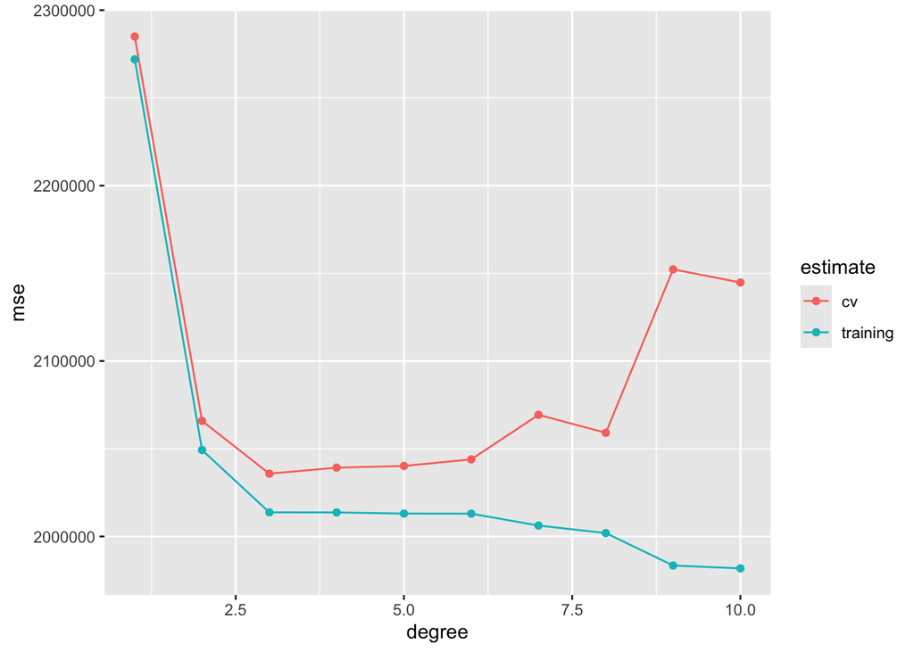

```
##    degree training      cv
## 1       1  2271973 2284983
## 2       2  2049282 2065887
## 3       3  2013756 2035785
## 4       4  2013705 2039214
## 5       5  2013037 2040177
## 6       6  2013014 2043920
## 7       7  2006207 2069339
## 8       8  2001939 2059099
## 9       9  1983431 2152266
## 10     10  1981805 2144763
```

```
## [1] 3
```

## B.3(b)

The cross-validated pinball loss of the fitted and shifted predictions, and the fraction of held-out days above each.

```
##          pinball     above
## fitted  596.8358 0.4746922
## shifted 236.6754 0.0998632
```